# Practice 2

CRASH

## Question 0

Add your name and the date to the R Markdown Header.

Insert a floating table of contents to the HTML.

## Question 1

This data was collected from www.theramenrater.com. It provides information on different reviews of ramen products, and has variables: Review #, Brand, Variety, Style, Country, Stars, and Top Ten.

#### (a)

Read in the Ramen data and check it carefully.

```r
ramen_ratings = read_csv("./data/ramen-ratings.csv")
```

#### (b)

Rename the first variable to be “review_number”, and the last variable to be “top_ten”. Additionally, ensure that the Stars column is saved as a numeric variable, and remove any non-numeric entries.

```r
ramen_ratings = ramen_ratings %>%
  clean_names() %>%
  filter(stars != "Unrated") %>%
  mutate(stars = as.numeric(stars))
```

#### (c)

Filtering just for the the ‘Nissin’ ramen brand, calculate the average rating for each country of this brand. What country has the highest rating of Nissin ramen? What country has the lowest rating?

```r
nissin_ramen_country = ramen_ratings %>%
  filter(brand == "Nissin") %>%
  group_by(country) %>%
  summarise(stars_mean = mean(stars))

low_to_high <- nissin_ramen_country %>%
  arrange(stars_mean)

high_to_low <- nissin_ramen_country %>%
  arrange(desc(stars_mean))
```

Answer:

The country with the highest average rating is Brazil and the country with the lowest average rating is the Philippines.

#### (d)

Create a new variable called “popular” which returns a 1 for entries that have a rating above or equal to 4.5 stars, and 0 for those that don’t.

```r
ramen_ratings = ramen_ratings %>%
  mutate(popular = if_else(stars >= 4.5, 1, 0))
```

#### (e)

Calculate the average stars for popular and not popular bowl ramen. Explain why (or why not) your results are meaningful.

```r
ramen_ratings %>% filter(style == "Bowl") %>%
  group_by(popular) %>%
  summarise(mean(stars))
```

```
## # A tibble: 2 × 2
##   popular `mean(stars)`
##     <dbl>         <dbl>
## 1       0          3.28
## 2       1          4.83
```

Answer:

This result is not meaningful. Summarizing by stars is redundant because the variable popular was created using the variable stars. It would not make sense to test the difference in stars between these two groups because we have defined them based on their star rating.

## Question 2

#### (a)

Read in NYC Airbnb data `AB_NYC_2019.csv`, and select only the: host_name, neighbourhood_group, room_type, price, minimum_nights, and number_of_reviews. Note, the neighborhood_group variable refers to borough.

```r
nyc_airbnb = read_csv("./data/AB_NYC_2019.csv") %>%
  select(host_name, neighbourhood_group, room_type, price,
         minimum_nights, number_of_reviews)
```

#### (b)

Create a new variable called minimum_price, which combines the minimum nights and price (per night) to give the minimum amount someone could pay to stay at the Airbnb.

```r
nyc_airbnb_mp = nyc_airbnb %>%
  mutate(minimum_price = minimum_nights * price)
```

#### (c)

Calculate the mean and median minimum_price using ‘summarize’. From these results, estimate whether you expect the data to be left or right skewed? Confirm your hypothesis by creating a histogram. Note, to improve the visualization of your histogram, consider removing very high prices.

```r
nyc_airbnb_mp %>%
  summarize(
    mean_min_price = mean(minimum_price),
    median_mean_price = median(minimum_price)
    )
```

```
## # A tibble: 1 × 2
##   mean_min_price median_mean_price
##            <dbl>             <dbl>
## 1          1284.               300
```

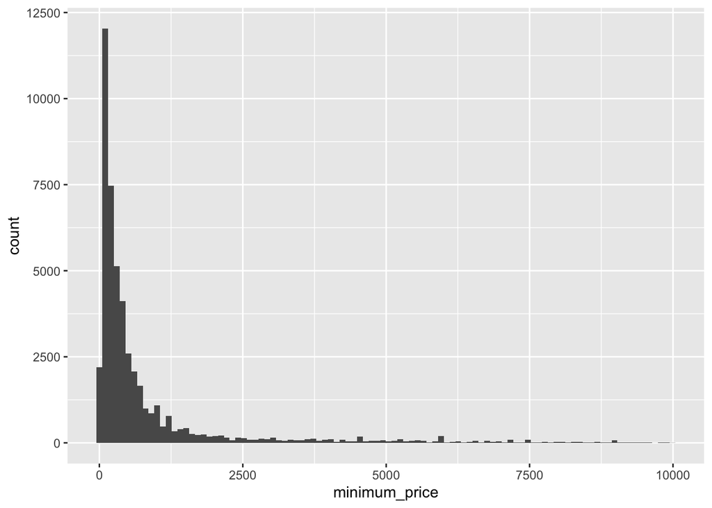

```r
nyc_airbnb_mp %>%
  filter(minimum_price < 10000) %>%
  ggplot() +
  geom_histogram(aes(x = minimum_price), bins = 100)
```

Answer:

The fact that the mean is so much larger than the median makes me think that this distribution will be right-skewed. Even after removing very high prices, we can see that the histogram confirms our suspicions: there is a long right tail to the distribution.

#### (d)

Are all of the New York City boroughs represented in the data? Prove your conclusion using the summarize function to show the number of observations in each borough.

```r
nyc_airbnb_mp %>%
  summarize(number_boroughs = n_distinct(neighbourhood_group))
```

```
## # A tibble: 1 × 1
##   number_boroughs
##             <int>
## 1               5
```

```r
# or

nyc_airbnb_mp %>%
  group_by(neighbourhood_group) %>%
  summarize(n = n())
```

```
## # A tibble: 5 × 2
##   neighbourhood_group     n
##   <chr>               <int>
## 1 Bronx                1091
## 2 Brooklyn            20104
## 3 Manhattan           21661
## 4 Queens               5666
## 5 Staten Island         373
```

```r
# anything that shows all five boroughs will work here
```

Answer:

Yes, all five boroughs are represented in the data.

#### (e)

Plot a boxplot of price across boroughs, showing only properties less than 1,000 a night. From the graph, which borough appears to have the highest median price? Which seems to have the lowest median price? Confirm this result using summarize and report the median price by borough.

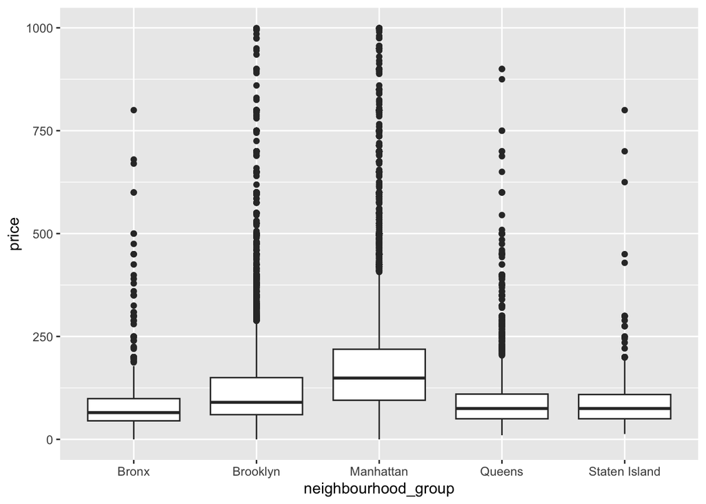

```r
#boxplot
nyc_airbnb_mp %>%
  filter(price < 1000) %>%
  ggplot() +
  geom_boxplot(aes(x = neighbourhood_group, y = price))
```

```r
#summarise
median_borough <- nyc_airbnb %>%
  group_by(neighbourhood_group) %>%
  summarize(median(price))

median_borough
```

```
## # A tibble: 5 × 2
##   neighbourhood_group `median(price)`
##   <chr>                         <dbl>
## 1 Bronx                            65
## 2 Brooklyn                         90
## 3 Manhattan                       150
## 4 Queens                           75
## 5 Staten Island                    75
```

#### (f)

What is the most commonly occurring host name? Re-write the code below using pipes and then report the answer in a sentence.

```r
#smelly code:
#arrange(summarise(group_by(nyc_airbnb, host_name), n = n()), -n)

#pleasant code
nyc_airbnb %>%
  group_by(host_name) %>%
  summarise(n = n()) %>%
  arrange(-n)
```

```
## # A tibble: 11,453 × 2
##    host_name        n
##    <chr>        <int>
##  1 Michael        417
##  2 David          403
##  3 Sonder (NYC)   327
##  4 John           294
##  5 Alex           279
##  6 Blueground     232
##  7 Sarah          227
##  8 Daniel         226
##  9 Jessica        205
## 10 Maria          204
## # ℹ 11,443 more rows
```

Answer:

The most common host name is Michael, as you can see in the printed table above.

## Question 3

#### (a)

You have been given a dataset for a study of a potential depression drug: `STUDYDAT12014.csv`. It includes treatment and placebo status, dose, age, along with HAM-D and HAM-A scores at baseline (`baseline_hamd` and `baseline_hama`) and at the end of the study (`outcome_hamd` and `outcome_hama`). Read in this dataset (`STUDYDAT12014.csv`) and report how many variables and how many observations are in this dataset.

```r
study = read_csv("./data/STUDYDAT12014.csv")
```

#### (b)

The investigators are interested in analyzing subjects who are at least 30 years old but less than 40 years old, so create a dataset which contains only observations from people within this age range. Use this dataset for all subsequent analyses.

```r
study_new = study %>%
  filter(age >= 30 & age < 40)
```

#### (c)

The treatment groups are currently labeled `pbo` and `trx`, but the researchers would like to have them labeled `Placebo` and `Drug 13XA`. Please make these changes to the dataset you created in (b)

```r
study_new = study_new %>%
  mutate(trx = ifelse(trx == "pbo", "Placebo", "Drug 13XA"))

## Please use the mutate function!
```

#### (d)

Create two new variables `hamd_diff` and `hama_diff` that are changes between baseline and outcome measurements for HAM-A and HAM-D.

```r
study_new = study_new %>%
  mutate(hamd_diff = baseline_hamd - outcome_hamd,
         hama_diff = baseline_hama - outcome_hama)
```

#### (e)

The investigators are interested in assessing whether there is a difference in (1) mean HAM-A changes between treatment groups and (2) mean HAM-D changes between treatment groups. Use t-tests (unequal variance) to test the difference between treatment groups for both of these outcomes. Be sure to report the test statistic, p-value, and degrees of freedom for each test in your write-up.

```r
#ham-a t-test
hama_test = t.test(hama_diff ~ trx, data = study_new)

#ham-d t-test
hamd_test = t.test(hamd_diff ~ trx, data = study_new)

## With equal variances:

#ham-a t-test
hama_test_e = t.test(hama_diff ~ trx, data = study_new, var.equal = TRUE)

#ham-d t-test
hamd_test_e = t.test(hamd_diff ~ trx, data = study_new, var.equal = TRUE)
```

Answer:

Unequal variance t-test:

The test for differences in HAM-A changes between treatment groups resulted in a test statistic of 1.0012236 with a df of 38.9376515 and a corresponding p-value of 0.3229005. Therefore, we fail to reject the null hypothesis and conclude there is not enough evidence of a significant difference in HAM-A change between treatment groups, at a level of significance of 5%.

The test for differences in HAM-D changes between treatment groups resulted in a test statistic of -0.8025073 with a df of 45.1303189 and a corresponding p-value of 0.4264656. Therefore, we fail to reject the null hypothesis and conclude there is not enough evidence of a significant difference in HAM-D change between treatment groups, at a level of significance of 5%.

Equal variance t-test:

The test for differences in HAM-A changes between treatment groups resulted in a test statistic of 1.0506664 with a df of 67 and a corresponding p-value of 0.2971867. Therefore, we fail to reject the null hypothesis and conclude there is not enough evidence of a significant difference in HAM-A change between treatment groups, at a level of significance of 5%.

The test for differences in HAM-D changes between treatment groups resulted in a test statistic of -0.7956345 with a df of 67 and a corresponding p-value of 0.4290544. Therefore, we fail to reject the null hypothesis and conclude there is not enough evidence of a significant difference in HAM-D change between treatment groups, at a level of significance of 5%.

## Question 4

#### (a)

You have been provided with a dataset from a student-run cafe `cafedata.xls`. This dataset contains data from a cafe, called Executive Express, run by undergraduate business students at a Midwestern public university. It was collected over a ten-week period from January to April 2010. Use what you have learned to read the data in, prepare it for analysis, and then calculate the necessary summary statistics to fill out the paragraph below, replacing the X’s with appropriate results.

```r
cafe = read_excel("./data/cafedata.xls", sheet = 2) %>%
  janitor::clean_names() %>%
  drop_na() %>%
  mutate(profitable = ifelse(sales >= 160, 1, 0), #create variable indicating profitability
         pastries_sold = muffins_sold + cookies_sold) #create variable combining cookie and muffin sales

cafe_sum = cafe %>%
  group_by(profitable) %>%
  summarise(n = n(),
            mean_wraps = mean(wraps_sold), sd_wraps = sd(wraps_sold),
            mean_pastries = mean(pastries_sold), sd_pastries = sd(pastries_sold),
            mean_coffees = mean(coffees), sd_coffees = sd(coffees))

cafe_profitable = filter(cafe_sum, profitable == 1)
cafe_unprofitable = filter(cafe_sum, profitable == 0)

# Unequal Variance
t_coffee = t.test(coffees ~ profitable, data = cafe)
t_wraps = t.test(wraps_sold ~ profitable, data = cafe)
t_pastries = t.test(pastries_sold ~ profitable, data = cafe)

#Equal Variance
t_coffee_e = t.test(coffees ~ profitable, data = cafe, var.equal = TRUE)
t_wraps_e = t.test(wraps_sold ~ profitable, data = cafe, var.equal = TRUE)
t_pastries_e = t.test(pastries_sold ~ profitable, data = cafe, var.equal = TRUE)
```

Answer:

Students called a day a ‘profitable day’, when they had at least $160 in sales. There were 18 ‘profitable’ days and 29 ‘unprofitable’ days.

On ‘profitable’ days, the mean number of wraps sold was 16.1111111 with a standard deviation of 6.8245999. On ‘unprofitable’ days, the mean number of wraps sold was 11.3103448 with a standard deviation of 4.3760994.

On ‘profitable days’, on average they sold 13.7777778 muffins and cookies combined, with a standard deviation of 7.352915. On ‘unprofitable days’, on average they sold 10.3103448 muffins and cookies combined, with a standard deviation of 6.5416438.

The mean number of coffees sold on ‘profitable’ days was 25.6111111 with a standard deviation of 8.4445519 and the mean number of coffees sold on ‘unprofitable’ days was 18.9655172 with a standard deviation of 11.8697778.

Unequal Variances:

When comparing profitable to nonprofitable days, there was a significant difference in coffee sold (p-value = 0.0303483, t=-2.2376848, df=44.0449661), and in wraps sold (p-value = 0.0131412, t=-2.6638622, df=25.7654393). However, the sales of muffins and cookies did not significantly differ between profitable and nonprofitable days (p-value = 0.1108585, t=-1.6383443, df=32.9745634), at a level of significance of 5%.

Equal Variances:

When comparing profitable to nonprofitable days, there was a significant difference in coffee sold (p-value = 0.044339, t=-2.0687955, df=45), and in wraps sold (p-value = 0.0050946, t=-2.9451445, df=45). However, the sales of muffins and cookies did not significantly differ between profitable and nonprofitable days (p-value = 0.0989822, t=-1.6846419, df=45), at a level of significance of 5%.

#### (b)

Create a graph that displays the distribution of coffee sales by day. Make sure the graph has the days ordered properly, as we would expect to see them on a calendar.

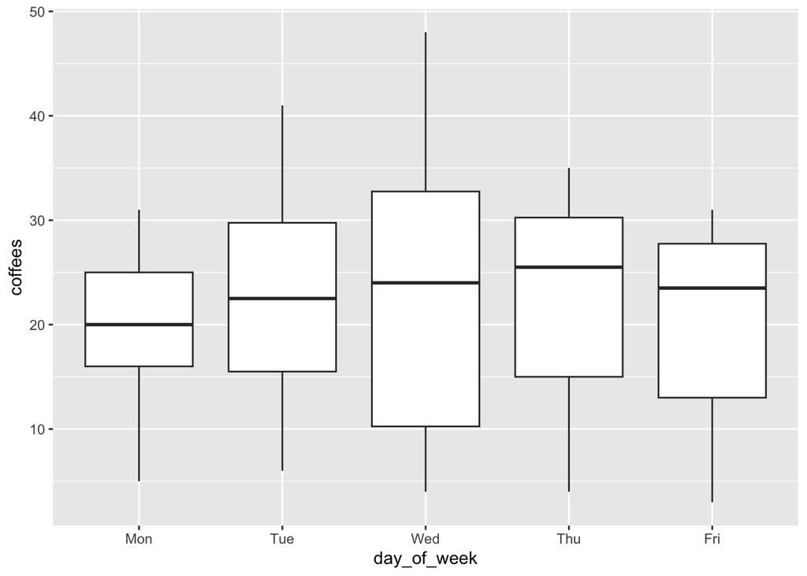

```r
cafe_fac = cafe %>%
  mutate(day_of_week = factor(day_of_week, levels = c("Mon", "Tue", "Wed", "Thu", "Fri")))

ggplot(data = cafe_fac) +
  geom_boxplot(aes(x = day_of_week, y = coffees))
```

Note: We were looking for boxplots by day of the week here, not a line graph over time.